# **Primer on the Bayesian Portfolio Optimization: Black-Litterman from a Bayesian Perspective**

@**Fintelligence Academy

8/26/2022

[figure not shown]

[figure not shown]

Figure 0.1: Prior&Posterior. Héliopolis, Temples de Baalbek. Beaux-Arts de Paris

> In this block, we provide an introduction of the classical **Black-Litterman (BL) model** in the general form. We present BL implementation details and a Bayesian interpretation of the model. Moreover, we introduce a novel **Bayesian Portfolio Optimization (BayPo)** framework extended from BL and formally uncover the Bayesian backbone behind the BL. This serves as a prequel to the Bayesian Portfolio Optimizaiton and we will give more dedicated introduction in the forthcoming piece.

# 1 Overview

The **Black-Litterman model** (see Black and Litterman [1990, 1991, 1992], He and Litterman [2002]), originating from former Goldman Sachs systematic investment group, is one of the most popular portfolio optimization models in quantitative finance, with numerous theoretical and industry practical achievements. From the standpoint of investment theory, the Black-Litterman model allows a seamless incorporation of *Bayesian statistics* into the **portfolio optimization process**. From a practical standpoint, it provides portfolio managers with a structured approach to express subjective views, thereby freeing their investment processes from a total reliance on backward-looking historical data.

The original **Black-Litterman (BL)** model essentially has five basic building blocks, as is shown below. The BL model allows portfolio managers to include their views (i.e., return expectations from forecast model) into the market implied returns (market prior).

- The capital asset pricing model (CAPM)
- Reverse optimization
- Bayesian estimation
- The concept of a universal hedge ratio
- Mean-variance optimization

## 1.1 Implied Expected Market Return $\mathbf{\pi}$ by CAPM

To set the scene of Black-Litterman model set-up, first, we consider a market with $n$ assets, whose returns are assumed to be normally distributed:

$$\mathbf{r} \sim \mathbf{N}(\mathbf{\mu}, \Sigma)$$
Where,

$\mathbf{r} \in \mathbb{R}^{n \times1}$ is a vector of the return of each asset,

$\mathbf{\Sigma} \in \mathbb{R}^{n \times n}$ is a variance-covariance matrix. It can be estimated from sample data, by applying some sort of shrinkage, or by commercial risk models,

$\mathbf{\mu}$ is a vector of the mean return of each asset.

In the light of the *Bayesian theory*, the $\mathbf{\mu}$ vector cannot be known with certainty. Rather, it is modeled as a random variable with estimation error. In the BL model, it is assumed to follow a normal distribution:

$$\mathbf{\mu} \sim \mathbf{N}(\mathbf{\pi}, \tau \mathbf{\Sigma})$$
Where, $\mathbf{\pi} \in \mathbb{R}^{n \times 1}$ is a vector containing the predicted return of each asset.

The parameter $\tau$ is where some of the *controversies* about the BL model arise. In the classical BL model, $\tau \mathbf{\Sigma}$ is the standard error matrix of the prior estimate. It reflects the fact that the uncertainty in the mean of the distribution is much smaller than the variance in the returns.

**Equilibrium Estimation** - To estimate $\mathbf{\pi}$, the BL model starts from the Markowitz [1952] model, where investors want to maximize risk-adjusted return:

$${argmax}_{\omega} \omega' \mathbf{\pi} - \frac{\lambda}{2} \omega' \Sigma \omega$$

Where,

$\mathbf{\omega}$ is a vector of holding weight of each asset to be solved

Investors try to maximize their expected returns, adjusted for their risk tolerance. The optimal (equilibrium) weight vector $\mathbf{\omega}$ can be solved by in a closed-form:

$$\mathbf{\omega} = (\lambda \Sigma)^{-1} \mathbf{\pi}$$

The closed-form solution is generally available only if there are no other constraints. In practice, portfolio managers often have constraints, e.g., country, sector, turnover, etc. and a numerical optimizer would have to be used.

By **reverse optimization**, we can obtain the implied expected market return vector:

$$\mathbf{\pi} = \lambda \Sigma \omega_{mkt}$$

## 1.2 Investor Views $\mathbf{q}$ under BL

View is a quintessential component of BL model, where investors could blend their multiple investment views into numerical model input as expected return. Here we introduce the view section of the BL model architecture.

Investors form their views in many different ways. Two typical approaches are:

- **Absolute view**: for example, we may have a model that predicts the return of a stock to be 5% over the next year; or
- **Relative view**: for example, our analysis may suggests that Stock B would outperform Stock C by 2% in the next 12 months

Both absolute view and relative view can be incorporated easily by a pick matrix $\mathbf{P} \in \mathcal{R}^{k \times n}$ and an expected return vector $\mathbf{q} \in \mathcal{R}^{k \times 1}$, where $k$ is the number of views that we want to express.

No model is perfect. Therefore, our views are *uncertain* and we should add an error term, $\mathbf{q}+\mathbf{\epsilon}$ where $\mathbf{\epsilon} \sim \mathcal{N}(\mathbf{0}, \mathbf{\Omega})$

**Investor Confidence** - Under the BL model, the error term is normally distributed with zero mean and a variance-covariance matrix of $\mathbf{\Omega}$, thus the confidence of our views is expressed by taking the inverse of the $\mathbf{\Omega}$ matrix as $\mathbf{\Omega}^{-1}$

Hence, investors’ views also follow a multivariate distribution:

$$\mathbf{P} \cdot \mathbb{E} [ \mathbf{r} ] \sim \mathcal{N}(\mathbf{q}, \mathbf{\Omega} \bigr)$$

The conditional equilibrium return vector is distributed as:

$$\mathbf{\pi} | \mathbb{E} [ \mathbf{r} ] \sim \mathcal{N} \bigl( \mathbb{E}[\mathbf{r}], \tau \mathbf{\Sigma})$$

## 1.3 BL Bayesian Posterior Esimation

After applying Bayes’ theorem, the *posterior probability of the expected return* vector $\hat{\mathbf{r}} = \mathbb{E} [ \mathbf{r} ] | \mathbf{\pi}$ follows a *multivariate normal distribution* with the following mean and variance.

$$\begin{equation}
\mathbf{\mu}_{\hat{\mathbf{r}}} = \bigl( ( \tau \mathbf{\Sigma})^{-1} + \mathbf{P}' \mathbf{\Omega}^{-1} \mathbf{P} \bigr)^{-1}
\bigl( ( \tau \mathbf{\Sigma})^{-1} \mathbf{\pi} + \mathbf{P}' \mathbf{\Omega}^{-1} \mathbf{q} \bigr)
\\
\mathbf{\Sigma}_{\hat{\mathbf{r}}} = \bigl( ( \tau \mathbf{\Sigma})^{-1} + \mathbf{P}' \mathbf{\Omega}^{-1} \mathbf{P}\bigr)^{-1}
\end{equation}$$

Assuming the uncertainty in the estimates is independent of the covariance of asset returns, the final covariance matrix $\mathbf{\Sigma}_{BL}$ is:

$$\begin{equation}
\mathbf{\Sigma}_{BL} = \mathbf{\Sigma} + \mathbf{\Sigma}_{\hat{\mathbf{r}}}
\end{equation}$$

Having attained the posterior expected return and covaraince, we could substitute the two as return and risk forecast and apply the conventional Mean-Variance Optimization (MVO) to derive the final optimal BL holdings $\mathbf{\omega}_{BL}$. In practice, this could be done by commercial portfolio optimizer.

To summarize, most investors use the BL model primarily to **combine views**, in order to have a more accurate and intuitive return prediction.

One featuring benefit of the BL framework is that it supposedly should also improve the risk estimation. The BL posterior covariance matrix $\mathbf{\Sigma}_{BL}$ is the sum of one standard prior risk estimates $\mathbf{\Sigma}$ (e.g., [Axioma’s fundamental equity factor risk model](https://qontigo.com/products/axioma-equity-factor-risk-models/)) and our view uncertainty $\mathbf{\Sigma}_{\hat{\mathbf{r}}}$.

# 2 Practical Implementation Manual with R Code

There are many ways to implement the BL model (see Walters [2013] for a nice summary). In this section, we discuss how we can incorporate the BL framework in real-life investing.

To implement the BL model, we need to estimate the following key parameters:

- **Scaling parameter $\tau=1$**. $\tau$ can have a significant impact on the final BL covariance matrix estimate. Many researchers typically choose a small value for $\tau$ to minimize potential adverse effect. The $\tau$ parameter often interacts with the view uncertainty matrix $\mathbf{\Omega}$, we could set $\tau=1$ to focus more on the view uncertainty, consistent with Meucci [2010].
- **Market risk aversion parameter $\lambda$**. $\lambda$ can either be set arbitrarily as a fixed number or can be estimated based on equity risk premium and the overall equity market risk.
- **Asset-by-asset covariance matrix $\mathbf{\Sigma}$**. Academic research mostly uses sample covariance matrix with shrinkage. Practitioners often use commercial risk vendors or in-house risk engine.
- **View return vector $\mathbf{q}$**. If analysts use scores (e.g., z-scores, quartiles, or rankings), we need to translate scores into expected returns by multiplying analysts’ skill and asset volatility. Therefore, we need to measure skill.
- **Uncertainty (or confidence) of views $\mathbf{\Omega}$ and the scaling parameter $\tau$**. If analysts use scores (e.g., z-scores, quartiles, or rankings), we need to translate scores into expected returns by multiplying analysts’ skill and asset volatility. Therefore, we need to measure skill.

The biggest challenge of the BL model is how to estimate these many parameters above, in particular, how to specify *views* and the *uncertainty of our views*.

## 2.1 Model Signal into Posterior Expected Return $\mathbf{\mu}_{BL}$

A quantitative alpha model usually has an estimated return for every stock in our investment universe. The pick matrix is therefore an identify matrix, i.e., $\mathbf{P}=\mathbf{I}$. Next, we derive the corresponding uncertainty matrix $\mathbf{\Omega}$:

$$\mathbf{\Omega} = \kappa \mathbf{P}' \mathbf{\Sigma} \mathbf{P} = \kappa \mathbf{\Sigma}$$

Inserting into the original BL model, we simplify the posterior expected return to:

$$\mathbf{\mu}_{BL} = \bigl( ( \tau \mathbf{\Sigma})^{-1} + \mathbf{P}' \mathbf{\Omega}^{-1} \mathbf{P} )^{-1}
\bigl( ( \tau \mathbf{\Sigma})^{-1} \mathbf{\pi} + \mathbf{P}' \mathbf{\Omega}^{-1} \mathbf{q} ) \\
= \frac{ \frac{ \mathbf{\pi} }{\tau}+ \frac{ \mathbf{q} }{\kappa} }{(\frac{1}{\tau}+ \frac{1}{\kappa})}$$
Hence, the posterior expected return is a weighted average of the market equilibrium return $\mathbf{\pi}$ and view expected return $\mathbf{q}$, weighted by the inverse of two scaling parameters $\tau$ and $\kappa$.

If the uncertainty of our view is different from $\mathbf{\Omega}=\kappa \mathbf{P} \mathbf{\Sigma} \mathbf{P}'$, we can insert $\mathbf{P} = \mathbf{I}$ into the original BL model and further express the mean and covariance matrix as:

$$\begin{equation}
\mathbf{\mu}_{BL} = \bigl( (\tau \mathbf{\Sigma})^{-1} + \mathbf{\Omega}^{-1} \bigr)^{-1} \bigl( (\tau \mathbf{\Sigma})^{-1} \mathbf{\pi} + \mathbf{\Omega}^{-1} \mathbf{q} \bigr)
\end{equation}$$

In particular, in the two *extreme examples* below where we are completely certain about our view or we have no confidence about our view, we can see:

- Extreme 1 - no uncertainty $\mathbf{\Omega} \rightarrow 0 \; \Rightarrow \; \mathbf{\mu}_{BL} = \mathbf{q}$
- Extreme 2 - no confidence $\mathbf{\Omega} \rightarrow \infty \; \Rightarrow \; \mathbf{\mu}_{BL} = \mathbf{\pi}$

## 2.2 Specifying Views – Expected Returns $\mathbf{q}$

Depending on how an investor forms his or her views, we can specify our expected return vector $\mathbf{q}$ accordingly.

Grinold and Kahn [2000] provide a guiding principle 📖 of *translating forecast (i.e., score) to expected returns*:

$$q_{excess} = IC \times \sigma_q \times score$$
Where,

$q_{excess} \in \mathbb{R}^{k \times 1}$ is a vector of expected returns, i.e., the views,

$IC$ - the Information Coefficient - is the correlation coefficient scalar value between our forecasts and realized returns, measuring the investment skill,

$\mathbf{\sigma}_{q} \in \mathbb{R}^{k \times k}$ is then the asset-by-asset volatility matrix of the $k$ assets for which we have views, and

$score \in \mathbb{R}^{k \times 1}$ is a vector of model scores.

Typical forecasts are of excess returns. Therefore, the expected nominal returns are:

$$\mathbf{q} = \mathbf{q}_{excess} + \mathbf{\pi}$$

## 2.3 Specifying Views Uncertainty – Uncertainty Matrix $\mathcal{\Omega}$

An effective way to specify the view uncertainty matrix $\mathcal{\Omega}$ is remaining a murky research area.

The classical way as many authors suggested is to link the uncertainty matrix $\mathbf{\Omega} \in \mathbb{R}^{k \times k}$ with the original asset-by-asset covariance matrix $\mathbf{\Sigma}$:

$$\mathbf{\Omega} = \kappa \mathbf{p} \mathcal{\Sigma} \mathbf{p}'$$

In this way, users only need to set the $\kappa$ parameter - a higher value of $\kappa$ corresponds to a higher uncertainty (lower confidence). The standard approach is intuitive and theoretically appealing. Naturally, we have higher (lower) confidence on assets that are less (more) volatile. Therefore, we can assume our uncertainty (or confidence) is proportional to each asset’s volatility (or variance).

[🤔] It is easy this way, but problematic. In reality, investors may want to set their confidence level $\kappa_k$ on each view/model $k$ differently. Intuitively, that confidence level could depend on, for example, a model’s historical accuracy/performance.

Assuming the view/model uncertainty is consistent over time, we could empirically estimate the model confidence by measuring the estimation error $\mathbf{q}_{err,t}$ as:

$$\mathbf{q}_{err,t} = \mathbf{q}_{real, t} - \mathbf{q}_t$$

where,

$\mathbf{q}_{real, t}$ is a vector of actual realized return at time $t$, and

$\mathbf{q}_t$ is a vector of return forecast formed at time $t$

Having obtained the historical performance of $\mathbf{q}_{real, t}$ time series, we could derive the empirical uncertainty matrix $\mathbf{\hat{\Omega}}$.

## 2.4 A Naive BL Example with Implementation in R

Let’s start from a simple example. Assuming that we have only two uncorrelated assets: A and B, with the following prior and view assumptions:

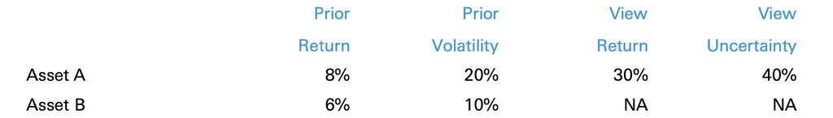

Since the two assets are uncorrelated, with our prior volatility assumption, we can derive our covariance matrix $\mathbf{\Sigma}$ as:

$$\mathbf{\Sigma} =\begin{bmatrix}
0.04 & 0\\
0 & 0.01
\end{bmatrix}$$
Furthermore, we introduce only one bullish absolute view on Asset A of 30% (i.e., $k=1$), which is much higher than the prior return of 8%. We understand that predicting asset return is extremely challenging; therefore, our view is highly uncertain with a standard deviation of 40%.

$$\mathbf{P} =\begin{bmatrix} 1 & 0 \end{bmatrix}, \\
\mathbf{q} = \begin{bmatrix} 30\% \end{bmatrix},\; \Omega = \begin{bmatrix} 0.16 \end{bmatrix}$$

The $\tau$ parameter is further set up as 1.

```r
## Prior
pi_rtn <- c(0.08, 0.06)    # mkt implied return
prior_sigma <- matrix(c(0.04,0,0,0.01), nrow = 2, ncol = 2)  # covariance matrix
tau <- 1   # scaling param

## View: k=1
pick_mat <- matrix(c(1,0), nrow = 1, ncol = 2)
q_rtn <- c(0.3)
omega_mat <- c(0.16)
```

Hence, we could derive the **BL posterior return expectation** as:

$$\mathbf{\mu}_{BL} = \bigl( (\tau \mathbf{\Sigma})^{-1} + \mathbf{P}' \mathbf{\Omega}^{-1} \mathbf{P} \bigr)^{-1}
\bigl( (\tau \mathbf{\Sigma})^{-1} \mathbf{\pi} + \mathbf{P}' \mathbf{\Omega}^{-1} \mathbf{q} \bigr) \\
= \bigl( \begin{bmatrix}
25 & 0\\
0 & 100
\end{bmatrix} + \begin{bmatrix}
6.25 & 0\\
0 & 0
\end{bmatrix} \bigr)^{-1} \bigl[25 \times 8\% + 6.25 \times 30\%, \; 100 \times 6\% + 0\bigr]^T \\
= \bigl[12.4\% ,\; 6\% ]^T$$

```r
prior_inv <- solve(tau*prior_sigma)   # (tau*Sigma)'
view_inv <-  t(pick_mat) %*% solve(omega_mat)   # (P'*Omega)'

mu_BL <- solve(prior_inv + view_inv%*%pick_mat) %*% (prior_inv%*%pi_rtn + view_inv%*%q_rtn)

mu_BL
```

```
##       [,1]
## [1,] 0.124
## [2,] 0.060
```

Moreover, we could calculate the BL posterior covaraince $\mathbf{\Sigma}_{BL} = \mathbf{\Sigma} + \mathbf{\Sigma}_{\hat{\mathbf{r}}}$ where

$$\mathbf{\Sigma}_{\hat{\mathbf{r}}} = \bigl( (\tau \mathbf{\Sigma})^{-1} + \mathbf{P}' \mathbf{\Omega}^{-1} \mathbf{P} \bigr)^{-1} \\
= \bigl( \begin{bmatrix}
25 & 0\\
0 & 100
\end{bmatrix} + \begin{bmatrix}
6.25 & 0\\
0 & 0
\end{bmatrix} \bigr)^{-1} =
\begin{bmatrix}
0.032 & 0\\
0 & 0.01
\end{bmatrix}$$

Lastly, the BL posterior covariance is
$$\mathbf{\Sigma}_{BL} = \mathbf{\Sigma} + \mathbf{\Sigma}_{\hat{\mathbf{r}}} \\
= \begin{bmatrix}
0.072 & 0\\
0 & 0.02
\end{bmatrix}$$
We can see the impact of our view on the covariance matrix from $\mathbf{\Sigma}_{\hat{\mathbf{r}}}$. The BL volatility of Asset A rises to 26.8% (from 20%), while the volatility of Asset B increases to 14.1% (from 10%).

> [📜] Setting a smaller value of the $\tau$ parameter would shrink the final covariance matrix towards the prior (i.e., both expected return and covariance matrix). For example, if we set $\tau=0.025$, the final volatilities of Assets A and B would be 20.2% (from 20%) and 10.1% (from 10%), respectively.

```r
#' Black-Litterman estiamte function
#' @return a list of BL posterior expected return and covariance
BL_posterior_estimate <- function(pi_rtn, prior_sigma, tau=1,
                                  pick_mat, q_rtn, omega_mat) {

  prior_inv <- solve(tau*prior_sigma)   # (tau*Sigma)'
  view_inv <-  t(pick_mat) %*% solve(omega_mat)   # (P'*Omega)'
  view_uncertainty <- solve(prior_inv + view_inv%*%pick_mat)   # Var(mu|pi)

  #### Posterior
  #  1) Expectation
  mu_BL <- view_uncertainty %*% (prior_inv%*%pi_rtn + view_inv%*%q_rtn)

  #  2) Covariance
  sigma_BL <- prior_sigma + view_uncertainty

  ## wrap up the result
  res <- list(mu=mu_BL, sigma=sigma_BL)
  return(res)
}


BL_posterior_estimate(pi_rtn, prior_sigma, tau=0.025,
                      pick_mat=pick_mat, q_rtn=q_rtn, omega_mat=omega_mat)
```

```
## $mu
##            [,1]
## [1,] 0.08136646
## [2,] 0.06000000
##
## $sigma
##            [,1]    [,2]
## [1,] 0.04099379 0.00000
## [2,] 0.00000000 0.01025
```

# 3 Black, Litterman, and the Spirit of Bayes

> [🌟] In the present note, we clarify the exact nature of the Bayesian statistical model to which Black–Litterman optimization corresponds, in terms of the prior, likelihood, and posterior. In the process we also lay out the full set of assumptions made, some of which are glossed over in other treatments.
- **Bayesian Priori Model of the Financial World**

  One of the crux of BL model design is to further consider the uncertainty of the expected return parameter $\mathbf{\mu}$ (i.e., input forecast signal) by the Bayesian perspective as a random vector with Gaussian prior mean $\mathbf{\pi}$ and covariance $\mathbf{C}$.

$$r \sim \mathcal{N}( \mathbf{\mu}, \mathbf{\Sigma}), \; \mathbf{\mu} \sim \mathcal{N}(\mathbf{\pi}, \mathbf{C})$$

## 3.1 Fundamentals of Bayesian Statistics

In language universally familiar to statistics and data science community (Robert, 2007), a Bayesian statistical model consists of:

- **Prior** - density function $\mathbf{\pi}(\mathbf{\theta})$ on the parameter $\mathbf{\theta}$ eliciting one’s own prior beliefs.
- **Likelihood** - a density function $f(\mathbf{x}| \mathbf{\theta})$ specifying the distribution of a vector-valued random variable $\mathbf{x}$, where realizations of $\mathbf{x}$ have been observed and only the parameter $\mathbf{\theta}$
- **Posterior** - is the density on $\mathbf{\theta}$ conditioning on observed data that is proportional to $f(\mathbf{x}| \mathbf{\theta}) \mathbf{\pi}(\mathbf{\theta})$, and the normalization factor can drop out of certain calculations. In Bayesian statistics, *all statistical inference is based on the posterior distribution*.

The Bayes rule (i.e., $q(\mathbf{\theta}|\mathbf{X}) \propto f(\mathbf{x}| \mathbf{\theta}) \mathbf{\pi}(\mathbf{\theta})$) guides to the update of posterior density $q(\mathbf{\theta})$ after observing the random sample $\mathbf{X}=(\mathbf{x}_1, ..., \mathbf{x}_n)$, yielding the posterior distribution density $q(\mathbf{\theta}|\mathbf{X})$ for Bayesian inference.

> [📜] A feature of Bayesian statistics that is dissimilar from frequentist statistics is the ability to perform inference in data-scarce situations. In Bayesian statistics, even a single observation can lead to valid inferences for multi-parameter models due to the presence of a prior. In essence, when less information is available, more weight is given to the prior.

The classic regression problem has the number of variables much less than the number of observations, and is therefore identifiable. However, the need to perform inference in models with many more variables than observations also arises in many appli- cations. Notably, this arises in the analysis of gene expression ar- rays, and is typically handled by Bayesian methods such as ridge and the lasso (see Tibshirani, 1996). In a nutshell, given $k$ model parameters, Bayesian could handle well the $n<k$ cases.

## 3.2 Bayesian Interpretation of Black–Litterman

> [📜] The BL method itself is often described as “Bayesian” but the original authors do not elaborate directly on connections with Bayesian statistics. The paper by Litterman and He (1999) contains many references to a “prior” but only one mention of a “posterior” without details, and no mention of a “likelihood”. This section present the linkage between BL to the Bayesian model and rigorously proves that BL is a specical case of more general Bayesian portfolio optimization.

Consider the view parameter $\mathbf{P}, \mathbf{q}$ with asset returns vector $\mathbf{r}$, it could be statistically expressed as

$$\mathbb{E}[ \mathbf{P}' \mathbf{r} ] = \mathbf{q}$$
In the language of statistics, the core idea of *Black and Litterman (1999)* is to treat the portfolio manager’s views as noisy observations which are useful for performing statistical inference concerning the parameters in some underlying model for $\mathbf{r}$. For example, if $r \sim \mathcal{N}( \mathbf{\mu}, \mathbf{\Sigma})$ with $\mathbf{\Sigma}$ a known positive-definite $n \times n$ variance-covaraince matrix, then the views can be recast as *“observations” relevant for Bayesian inference on the parameter set $\mathbf{\mu}$*.

A key and enigmatic aspect of the model is that the practitioner must also specify a level of *uncertainty or “error bar” for each view*, which is assumed to be an independent source of noise from the volatility already accounted for in a model. This is expressed as the following more precise restatement:

$$\begin{equation}
\mathbf{P} \mathbf{\mu} = \mathbf{q} + \mathbf{\epsilon} \\
\mathbf{\epsilon} \sim \mathcal{N}(\mathbf{0}, \mathbf{\omega})
\end{equation}$$

Portfolio managers in this model specify noisy, partial, indirect information about $\mathbf{\mu}$ through their views. The information is partial and indirect because the views are on portfolio returns, i.e., linear transformations of returns, rather than on the asset returns directly.

A subjective, uncertain view about what will happen to a certain portfolio in the future is conceptually distinct from a noisy experimental observation such as an attempt to measure some physical constant with imperfect laboratory equipment. Nonetheless, for building intuition, we suggest thinking of a portfolio managers’ forecast as an “observation of the future” in which the measuring device is a rather murky and unreliable crystal ball. Only in this way is it analogous to the noisy measurements in experimental design which much of statistics is designed to model.

Black and Litterman essentially say that the portfolio manager’s view, if it is worth anything, should contain some (noisy) information about the future, so the view is, mathematically, no different from a noisy observation of a realization of (a linear transformation of) future returns.

## 3.3 Statistical Likelihood Model Behind the BL Hood

As noted above, to perform statistical inference, observations alone are not sufficient; one needs to fully specify the statistical model, which includes a likelihood and a prior. The likelihood is specified via the view likelihood model as:

$$\begin{equation}
f(\mathbf{q} | \mathbf{\mu}) \propto \exp \bigl\{ -\frac{1}{2} ( \mathbf{P} \mathbf{\mu} - \mathbf{q})' \mathbf{\Omega}^{-1} (\mathbf{P} \mathbf{\mu} - \mathbf{q}) \bigr\}
\end{equation}$$

## 3.4 Market Prior from CAPM Equilibrium

Black and Litterman were motivated by the guiding principle that, in the absence of any sort of information/views which could constitute alpha over the benchmark, the optimization procedure should simply return the global CAPM equilibrium portfolio with market portfolio holdings $\omega_{mkt}$. Henceforth, in the absence of any views, a **market prior $\mathbf{\pi}$** can be derived.

It starts by modeling the asset returns with prior mean $\mathbf{\pi}$:

$$r \sim \mathcal{N}( \mathbf{\mu}, \mathbf{\Sigma}), \; \mathbf{\mu} \sim \mathcal{N}(\mathbf{\pi}, \mathbf{C})$$
for some exogenous covariance whose inverse represents the *amount of precision in the prior*. In particular, BL model has a formulation for $\mathbf{C}$ with a scalar hyperparameter **$\tau>0$** and thus $\mathbf{C}=\tau \mathbf{\Sigma}$.

Under the CAPM market equilibirum, mean–variance optimization with risk-aversion parameter $\lambda$ yields the prior mean $\mathbf{\pi}$, or implied market expected return:

$$\mathbf{\pi} = \lambda \Sigma \omega_{mkt}$$

Zooming back to the discretionary view equation, we have the bridge equation between view vector $\mathbf{q}$ and prior, which is the Bayesian investor’s model of the world

$$\mathbb{E} [ \mathbf{P}' \mathbf{r} ] = \mathbf{P}' \mathbf{\pi} \\
\mathrm{Var}[ \mathbf{P}' \mathbf{r} ] = \mathbf{P}' ( \mathbf{\Sigma} + \mathbf{C} ) \mathbf{P}$$
[🤔] In fact we must make a choice whether to use the conditional or unconditional variance in optimization: $\mathrm{Var}( \mathbf{r} | \mathbf{\mu} ) = \mathbf{\Sigma}$ or $\mathrm{Var}( \mathbf{r} ) = \mathbf{\Sigma} + \mathbf{C}$

## 3.5 Posterior for Expected Asset Returns $\mathbf{\tilde{\mu}}$

**Desirable Gaussian Prior** - we now have the *normal likelihood* and the *normal prior* which is a **conjugate prior** for that likelihood, meaning that the posterior is of the same family (i.e. also *normal distributed* in this example) 👏.

The negative log posterior is thus proportional to (neglecting terms that do not contain $\mathbf{\mu}$):

$$( \mathbf{P} \mathbf{\mu}-q )' \mathbf{\Omega}^{-1} (\mathbf{P} \mathbf{\mu}-q ) +
(\mathbf{\mu} - \mathbf{\pi})' \mathbf{C}^{-1} (\mathbf{\mu} - \mathbf{\pi} )$$
Leveraging some useful Bayesian lemmas, we could attain an explicit form for posterior mean $\mathbf{\tilde{\mu}}$:

$$\mathbf{\tilde{\mu}} = \bigl( \mathbf{C}^{-1} + \mathbf{P}' \mathbf{\Omega}^{-1} \mathbf{P} )^{-1}
\bigl( \mathbf{C}^{-1} \mathbf{\pi} + \mathbf{P}' \mathbf{\Omega}^{-1} \mathbf{q} )$$
and posterior covariance $\mathbf{\tilde{\Sigma}}$:

$$\mathbf{\tilde{\Sigma}} = \mathbf{H}^{-1} = \bigl( \mathbf{C}^{-1} + \mathbf{P}' \mathbf{\Omega}^{-1} \mathbf{P} \bigr)^{-1}$$

Finally, we stepped to the core formulation of the Bayesian portfolio optimization, which is in essence a decision optimization problem under the uncertainty measured by Bayesian posterior distribution.

$$\begin{equation}
\mathbf{\omega}^* = argmax_{\omega} \mathbb{\tilde{E}}[ \mathbf{\omega}'\mathbf{r}] - \frac{\lambda}{2} \tilde{\mathrm{Var}}[\mathbf{\omega}'\mathbf{r}]
\end{equation}$$

Where $\mathbb{\tilde{E}}[\mathbf{r}]$ and $\tilde{\mathrm{Var}}[\mathbf{r}]$ denote, respectively, the unconditional mean and covariance of return under the posterior. [🤔] The unconditional covariance is a sum of variance due to parameter uncertainty, and variance due to the randomness in $r$. In other words,

$$\begin{equation}
\mathrm{Var}[ \mathbf{\omega}'\mathbf{r} ] = \mathbf{\omega}' [ \mathbf{P}' \mathbf{\Omega}^{-1} \mathbf{P}' + \mathbf{C}^{-1} ]^{-1} \mathbf{\omega} + \mathbf{\omega}' \mathbf{\Sigma} \mathbf{\omega}
\end{equation}$$

Without further constraints, the optimal Bayesian portfolio solution $\mathbf{\omega}^*$ accounting for both types of variance is then:

$$\begin{equation}
\mathbf{\omega}^* = \lambda^{-1} [\mathbf{H}^{-1} + \mathbf{\Sigma}]^{-1} \mathbf{H}^{-1} \bigl[ \mathbf{C}^{-1} \mathbf{\pi} + \mathbf{P}' \mathbf{\Omega}^{-1} \mathbf{q} \bigr]
\end{equation}$$

## 3.6 BL: A Special Case of Bayesian Portfolio Optimizaton

The Black and Litterman model is the special case of Bayesian Portfolio Optimization in which $\mathbf{r}|\mathbf{\mu}$ is multivariate normal with mean $\mathbf{\mu}$ and $f(\mathbf{q}|\mathbf{\mu})$ is the normal likelihood for a regression of the portfolio manager’s views.

[📜] An interesting feature of the model is that there are two functions which both play the role of likelihood functions:

- $p(\mathbf{r} | \mathbf{\mu})$ return density
- $f(\mathbf{q} | \mathbf{\mu})$ view model

Equivalently, we have a triplet of random vectors: $(\mathbf{r}, \mathbf{q}, \mathbf{\mu})$, which are not pairwise independent, but $\mathbf{r} \in \mathbb{R}^{n \times 1}$ and $\mathbf{q} \in \mathbb{R}^{k \times 1}$ are conditionally independent given $\mathbf{\mu}$. In Bayesian statistics, such situations are commonplace. A Bayesian network (or “graphical model”) is, intuitively, an arbitrary collection of random variables whose conditional independence structure is specified by a (typically directed and acyclic) graph, so this system could be considered a Bayesian network with three nodes.

[💡] Phrasing things in this way inspires the imagination of the modeling for $\mathbf{\mu}$. Even if $\mathbf{\mu}$ simply represents the mean vector of asset returns, such returns are widely recognized to be non-normal.

Replacing $r \sim \mathcal{N}( \mathbf{\mu}, \mathbf{\Sigma})$ with a Laplace distribution may fit empirical asset returns more accurately. This corresponds to Least absolute deviation (LAD) regression.

More generally, $\mathbf{\mu}$ is allowed to be any set of parameters $\mathbf{\theta}$ appearing in a parametric statistical model for asset returns, not necessarily their means.

# 4 Application #1: Combining Quantitative and Fundamental Analysis

## 4.1 Quantamental Background

Quantitative models and fundamental analysis specialize on different dimensions – models tend to have high breadth (i.e., they cover many stocks), but fundamental analysis excels at depth (i.e., stronger predictive power on fewer stocks). More importantly, these two investment strategies might be uncorrelated, which provides diversification benefit.

Quantitative analysts and fundamentals analysts tend to see the world differently. The **Black-Litterman model** seems to be a sensible solution.

*Sell-side analysts* are predominantly fundamental analysts. They rate the stocks they cover as “Strong Buy”, “Buy”, “Hold”, “Sell”, and “Strong Sell”. Sell-side analysts are often organized by industries; therefore, each analyst typically only covers stocks in the same industry. Furthermore, instead of using the absolute levels of recommendations, we use three-month recommendation revisions as our fundamental view, i.e., (Current consensus rating – Consensus rating three months ago)/Consensus rating three months ago. What really matters is whether the sell-side is *revising their views upwards or downwards* for a given stock.

## 4.2 The Black-Litterman Approach to Incorporate Fundamental Views

### 4.2.1 Model Setup

We need to specify the many parameters in order to perform the BL analysis.

- The **View Return vector $\mathbf{q}$** depends on a manager’s skill ( ${IC}_{t}$ ). For simplicity, arbitrarily set it as 5% for analyst revision. The 5% IC corresponds to a good manager.
- We estimate the **View Uncertainty variance $\mathbf{\Omega}$** using five-year rolling data

### 4.2.2 BL Portfolio Construction

- Objective Function: $argmax_{\mathbf{\omega}} \mathbf{\omega}' \mathbf{\pi} - \frac{\lambda}{2} \mathbf{\omega}' \mathbf{\Sigma} \mathbf{\omega}$

The tracking error of a typical fundamental portfolio tends to be high. The BL approach shrinks analyst recommendations toward the market consensus views; therefore, BL portfolios have lower tracking error, but hold more stocks.

### 4.2.3 Combining Fundamental and Quantitative Views

> [💡] On many realistic trading applications, we have a model that has strong predictive power, but it has limited breadth, i.e., it only covers a small fraction of the market. This is where the BL model shines, as it does not require us to have views on every single asset.

In this section, we combine fundamental (proxied by analyst recommendations by the pick $\mathbf{P}_F$ and view return $\mathbf{q}_{F}$) and quantitative views together (as measured by the pick $\mathbf{P}_Q$ and view return $\mathbf{q}_{Q}$), using the BL framework.

We can simply stack up together our fundamental views and quantitative models to form the pick matrix, view return vector, and view uncertainty matrix.

$$\mathbf{P}_\alpha = \begin{pmatrix} \mathbf{P}_F \\ \mathbf{P}_Q \end{pmatrix}, \;
\mathbf{q}_\alpha = \begin{pmatrix} \mathbf{q}_F \\ \mathbf{q}_Q \end{pmatrix}, \;
\mathbf{\Omega}_\alpha = \begin{pmatrix} \mathbf{\Omega}_F & 0 \\ 0 & \mathbf{\Omega}_Q \end{pmatrix}$$

# 5 Application #2: Event Overlay

- Traditionally, events are not part of quantitative portfolio managers’ factor models. Events come at irregular frequency; while traditional stock-selection factors are regularly spaced (e.g., daily, weekly, monthly, or quarterly). Event databases can also be expensive; therefore, investors are unsure whether the benefit outweighs the cost.
- Asset owners (e.g., pension funds, insurers, foundations, endowments, family offices and sovereign wealth funds), funds of funds, and asset allocation funds start to show increasing interest in ways to systematically capture event premia. For example, traditionally, when a pension fund wants to capture activist event premia, it would either invest in an activist hedge fund or build out an internal team to conduct activist investing. Both can be quite expensive. There are systematic approaches that can at least partially replicate the return stream of such investment styles.

## 5.1 BL Translating Discrete Event to Continuous Signal

There are a few things that are unique to events when we specify the BL model:

- **Event Pick Matrix**. For absolute views, the row of the pick matrix is not that different from the previous sections. For relative views, for example for CEO changes, at each month, we propose that there are $N_{long}$ positive events and $N_{short}$ events, then we could set up equal weight for long and short side respectively.
- **Event Skill ${IC}_{event}$** is set as a constant number for an event type based on the annual alpha. The view uncertainty matrix $\mathbf{\Omega}_{event}$ is assumed to be determined by

$$\mathbf{\Omega}_{event} = \tau_{event} \mathbf{P \Sigma P'}$$
The event signal is clearly uncorrelated to the consensus market equilibrium returns. The excess returns from most corporate events tend to be uncorrelated to common risk factors, including the overall market. On the other hand, the BL posterior return heavily depends on the event signal, due to the strength of the event signals and relatively modest view uncertainty.

With the BL framework, we have an expected return for each stock in our investment universe, regardless if there is an event for the stock or not. Constructing a portfolio becomes much easier and the portfolio also tends to be more intuitive.

# 6 Conclusion

**Black and Litterman approach (BL)** is an elegant and systematic way to mix multiple (and often conflicting) views into investable portfolio. The biggest challenge in implementing the BL model is how to estimate the many input parameters. In particular, investors need to specify their views following the rigid BL set-up – the return expectation and the uncertainty of their opinions.

**Bayesian Philosophy** - BL model’s appeal stems from its roots in Bayesian statistics, which provides the mathematical tools to combine investors’ forward-looking subjective views with a market-based prior. BL could be intuitively regarded as an Bayesian extension of Markowitz Mean Variance Optimization by blending the CAPM market equilibrium prior with forward-looking investor view. A more generic *Bayesian Portfolio Optimization (BayPo)* framework is introduced with flexible prior or distribution choice available to upgrade beyond the baseline BL.

**key Model Assumptions** - as we saw in the previous section, BL mainly relies on the following model assumptions:

- Assumption 1. BL model assumes that security returns are *normally distributed*. The advantage of using this assumption within a modeling framework is that it imbues the model with mathematical tractability and transparency. The disadvantage, as we noted above is that it often leads to an inaccurate picture of asset behavior.
- Assumption 2. The view formulation of BL model assumes that investment views are expressed as of *linear portfolios* of the assets. This is the beauty of the simplicity of BL model and functions as the core instrument combining multiple alpha sources (e.g., model output or trading ideas) into the portfolio optimization process. The *specification of view uncertainty* is a tricky component though with only ad-hoc model choice available.
- Assumption 3. The third major simplifying assumption of the original BL model is that prior returns can be reliably derived from the *CAPM market equilibrium portfolio*. However, it is commonly accepted that there are a number of additional factors in addition to the market factor that are important for the derivation of prior returns. This is especially so for portfolios of multiple asset classes.

We conclude that the primary advantage of the original BL framework is its *simplicity and flexibility*. Simplicity is an important feature of any working model and indeed, one of the reasons that the BL model became widely adopted in the first place. However, there is a trade-off between model simplicity and accuracy. In the latter vein, the original BL model is incomplete for modern practical applications and limited as a special case of BayPo framework. More comprehensive model set-ups could be upgraded over the BL and improve the accuracy and robustness of the Bayesian family model.

Since the introduction of the Black-Litterman model in the early 1990s, there has been significant advancements in statistical inference techniques, often driven by advances in machine learning and the need to analyze large complex datasets in real-time. Moreover, many practical problems in finance require inference in “data scarce” situations where the number of parameters may greatly exceed the number of observations. The Bayesian portfolio optimization is thus as relevant as ever. In the high level sense, BayPo can be a robust systematic framework to ingest more rich information into the portfolio construction process beyond the Mean Variance Optimization via the *prior* and *view* channel.

# 7 References

Black, F., and Litterman, R. [1990]. “Asset Allocation: Combining Investors Views with Market Equilibrium”, Fixed Income Research, Goldman, Sachs & Company, September 1990.

Black, F., and Litterman, R. [1991]. “Global Asset Allocation with Equities, Bonds, and Currencies”, Fixed Income Research, Goldman, Sachs & Company, October 1991.

Black, F., and Litterman, R. [1992]. “Global Portfolio Optimization”, Financial Analyst Journal, September/October, 28-42.

Grinold, R.C., and Kahn, R.N. [2000]. Active Portfolio Management: A Quantitative Approach for Providing Superior Returns and Controlling Risk, McGram-Hill.

He, G. and Litterman, R. [1999]. “The Intuition Behind Black-Litterman Model Portfolios”, Investment Management Research, Goldman, Sachs & Company, December 1999.

Kolm, P.N., Ritter, G. and Simonian, J. [2021]. “Black–Litterman and Beyond: The Bayesian Paradigm in Investment Management”, The Journal of Portfolio Management, 47(5), pp.91-113.

Litterman, R. and the Quantitative Resources Group, Goldman Sachs Asset Management. [2003]. Modern Investment Management: An Equilibrium Approach. New Jersey: John Wiley & Sons.

Meucci, A. [2005]. “Beyond Black-Litterman: Views on Non-Normal Markets”, November 2005, SSRN Working Paper.

Meucci, A. [2008]. “The Black-Litterman Approach: Original Model and Extensions”, April 2008, SSRN Working Paper.

Robert, C. (2007). The Bayesian choice: From decision-theoretic foundations to compu- tational implementation. Springer Science & Business Media.

Walters, J. [2013]. “The Factor Tau in the Black-Litterman Model”, SSRN Working Paper.